# Análisis espacial de superficies (Índice SADIE)

# 1 Carga de datos y paquetes

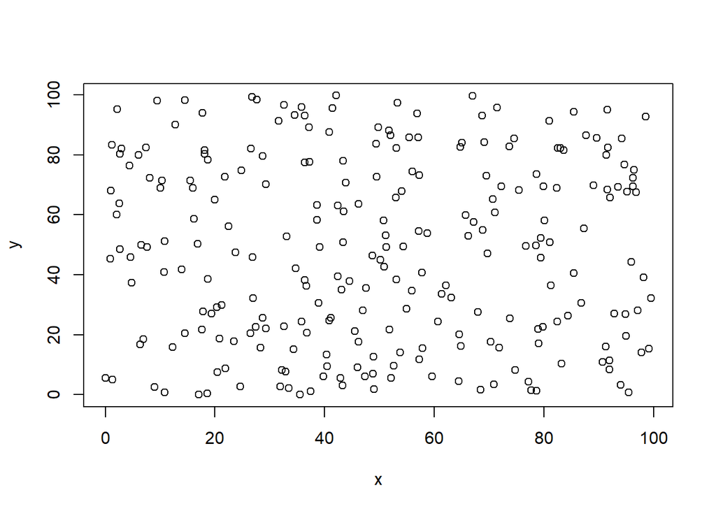

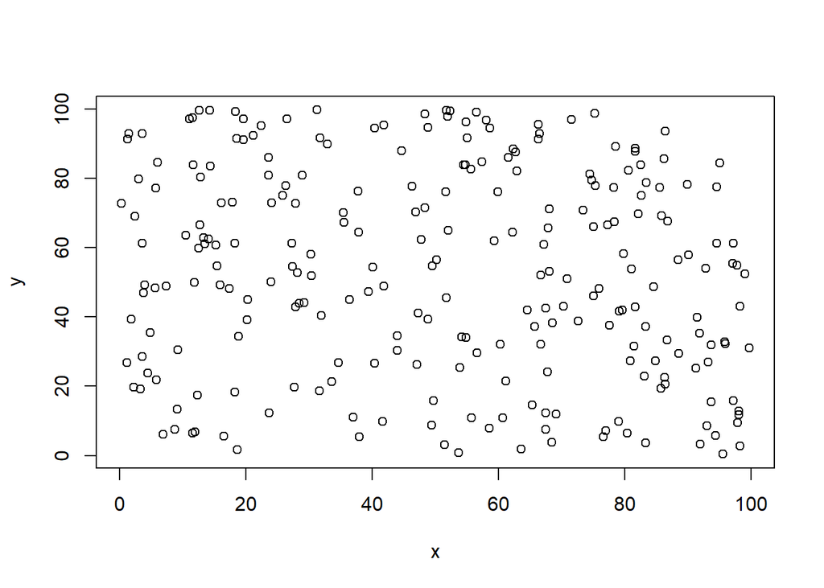

# 2 Análisis SADIE

```r
# 3. Calculo de SADIE
# 3.1. 1º base de datos
base1 <- lista_dfs[[1]] %>%
  sadie(
    index = "all",
    nperm = 100,
    seed = 123,
    threads = 3,
    verbose = FALSE
  )

summary(base1)
```

```
Call:
sadie.data.frame(data = ., index = "all", nperm = 100, seed = 123,
    threads = 3, verbose = FALSE)

First 6 rows of clustering indices:
         x          y  i cost_flows      idx_P    idx_LMX      prob
1 96.25509 72.3442695 41 -13.320944 -2.1308768 -2.0060134 0.1188119
2 60.64529 24.4330222 74   9.205751  0.8516475  0.8018227 0.6039604
3 71.43047 95.8011351 99  11.806136  0.9408774  0.9848322 0.5148515
4 76.71198 49.5566535 60   7.387992  0.8810949  0.6936201 0.5247525
5 53.74200 14.0637818 72   5.280614  0.6278086  0.5353031 0.6534653
6 10.87629  0.8086437 41  -9.416074 -1.0866774 -1.1682846 0.3762376

Summary indices:
                       overall     inflow   outflow
Perry's index        0.8003709 -0.8357622 0.7649796
Li-Madden-Xu's index 0.8089378 -0.8361250 0.7817505

Main outputs:
Ia: 0.7891 (Pa = 0.99)

'Total cost': 1026.763
Number of permutations: 100
Fixed seed: 123
```

```r
# 3.2. 2º base de datos
base2 <- lista_dfs[[2]] %>%
  sadie(
    index = "all",
    nperm = 100,
    seed = 123,
    threads = 3,
    verbose = FALSE
  )
```

[output not shown]

```r
summary(base2)
```

```
Call:
sadie.data.frame(data = ., index = "all", nperm = 100, seed = 123,
    threads = 3, verbose = FALSE)

First 6 rows of clustering indices:
         x        y  i cost_flows      idx_P    idx_LMX       prob
1 17.79041 73.21259 30  -1.710455 -0.1896019 -0.1812054 0.81188119
2 58.65109 94.43712 78  17.827198  2.1911050  2.1356855 0.06930693
3 82.49919 83.91820 81   5.544881  0.8206825  0.7595133 0.49504950
4 39.36195 47.35674 11  -2.889593 -0.2332128 -0.2589229 0.92079208
5 37.92987  5.46538 30 -17.345243 -1.1532955 -1.1550649 0.36633663
6 93.20721 26.90596 21  -2.509396 -0.2803721 -0.3082926 0.86138614

Summary indices:
                      overall    inflow  outflow
Perry's index        1.067831 -1.054265 1.083253
Li-Madden-Xu's index 1.056626 -1.054566 1.058968

Main outputs:
Ia: 1.0234 (Pa = 0.41)

'Total cost': 1205.256
Number of permutations: 100
Fixed seed: 123
```

Como puede apreciarse, la **1º base de datos** presenta un $I_a =$ 0.7891032, por lo que presenta un patrón regular ($I_a < 1$), aunque este resultado no es significativo ($p \ valor$ =0.99). Por otro lado, la **2º base de datos** presenta un $I_a =$ 1.023446, por lo que presenta un patrón ligeramente agregado ($I_a > 1$), aunque de nuevo este resultado no es significativo ($p \ valor$ =0.41).

En ambos casos, el `p-valor` es considerablemente mayor que `0.05`, por lo que, en ambos casos, no existe evidencia significativa de agregación/regularidad espacial.